# Lotek twilight times with SGAT

Michael Sumner

2014-09-01

The `SGAT` package provides a range of methods for estimating geolocation given either estimated times of twilight or the light profiles from each twilight. In particular, `SGAT` provides

- the simple *threshold* method implemented in the `GeoLight` package
- the *template* or *curve fitting* method implemented in the `tripEstimation` package, and
- a new *threshold* based variant of the algorithm from the `tripEstimation` package.

This third method is better suited to some tag data than the original `tripEstimation`, and especially here since we only have times of Sunrise and Sunset. Ultimately, the intention is for `SGAT` to supersede `tripEstimation` and `GeoLight`.

In this document we will demonstrate the threshold based variant of the `tripEstimation` method.

## Data

We have a Lotek “Day Log” file for two birds deployed at Tern Island. The first is a Laysan albatross deployed between March 2009 and January 2010 and the second a Black-footed albatross deployed between March 2010 and December 2010.

```r
#   LAT250_0833_100106_L150_151726779_00.TXT
# Species: Laysan albatross
# Deployed at Tern Island, FFS:  23.87 ;-166.29
# Deployment date: Mar 11 2009
# Recovery date: Jan 06 2010
# No sightings mid deployment*
#
# LAT250_0835_101207_B122_151774036_00.TXT
# Species: Black-footed albatross
# Deployed at: Tern Island, FFS:  23.87 ;-166.29
# Deployment date: Mar 07 2010
# Recovery date: Dec 07 2010
# No sightings mid deployment*

# *A thing to note is that the birds will be returning to the colony
# 1x to 2x a month until late June/July to feed their chick. After July
# they are "officially" on their postbreeding trip and shouldnt be returning
# to the colony until ~ November.
#
```

These files contain sunrise and sunset times, as well as Lotek-derived locations. Here we aim to generate independent location estimates using a “threshold-sensitivity” approach from the **SGAT** package. There are other examples where activity and SST data are also available, but for now we just look at one example using the sunrise and sunset times only.

First, read the raw data from the file ensuring we have sensible interpretation of the values.

```r
library(SGAT)
##library(BAStag)

dp <- "."
f1 <- "LAT250_0833_100106_L150_151726779_00.TXT"

## hardcoded structure of this file
ltkclasses <-  c("integer", "character", "integer", "integer", rep("numeric", 6), rep("integer", 4), "numeric", "integer", rep("numeric", 2))
rawd <- read.table(file.path(dp, f1), skip = 2, comment.char = "*", sep = ",", header = TRUE,
                colClasses = ltkclasses)
```

Record some details that we know about this tag, the deployment date will be used to ignore data prior to this time.

```r
lon.home <- -166.29 + 360
lat.home <- 23.87
deploy.time <- as.POSIXct("2009-03-11 00:00:00", tz = "GMT")

## maximum range in lon/lat (for land mask plus maximum bound of track)
lon.range <- c(140, 210)
lat.range <- c(10, 65)
```

We need to extract the raw sunrise and sunset values, and later we will use the pre-estimated locations so we save those to a new object separate from the raw data. The longitudes are in the “Atlantic view” range (-180,180) so we modify these to span the “Pacific View”, and apply simple clean up for the raw data.

```r
 ldata <- data.frame(lon = rawd$Longitude..degs., lat = rawd$Latitude..degs.,
                    date = as.POSIXct(as.Date(rawd$Date...Time, "%m/%d/%Y")),
                    RiseMinute = rawd$Sunrise,
                    SetMinute = rawd$Sunset)
## out of bounds is 65535, also a 2527 value at 2009-03-08
##ldata <- ldata[pmax(ldata$SetMinute, ldata$RiseMinute) < 2500, ]
ldata <- ldata[ldata$date >= deploy.time, ]
ldata$lon[ldata$lon < 0] <- ldata$lon[ldata$lon < 0] + 360
```

Plotting the intervals of the rise and set minutes as relative to a time sequence gives a day to day profile of the light seen by the tag.

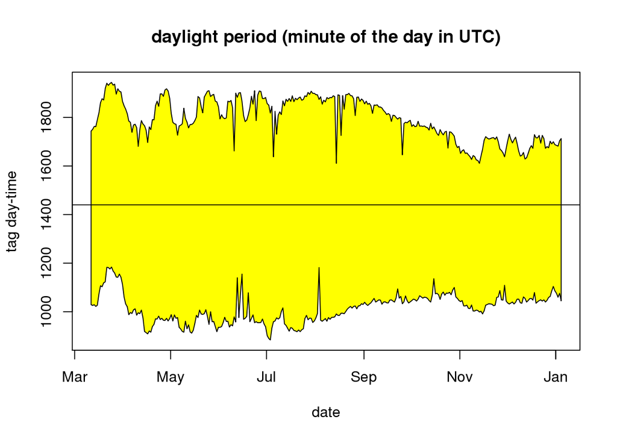

```r
plot(RiseMinute ~ date, type = "n", ylim = range(c(RiseMinute, SetMinute)),  data = ldata, ylab = "tag day-time")
polygon(c(ldata$date, rev(ldata$date)), c(ldata$RiseMinute, rev(ldata$SetMinute)), col = "yellow")
abline(h = 1440)
title("daylight period (minute of the day in UTC)")
```

## Location estimation- naive threshold

Create the “twilight” data for input to traditional threshold estimation with “Rise” and “Set” as absolute times. Choose a reasonable zenith, with a bit of experimentation this one seems close to what must have been used by Lotek.

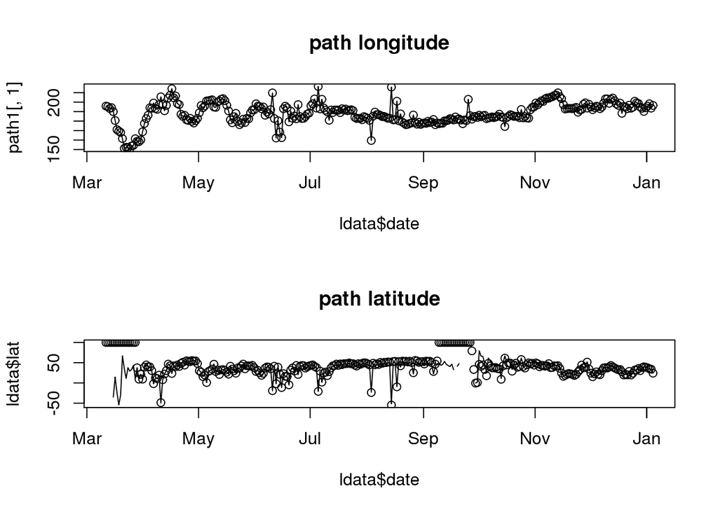

```r
twl <- data.frame(Rise = ldata$date + ldata$RiseMinute * 60,
                  Set = ldata$date + ldata$SetMinute * 60)

## we don't know the zenith, so guess until the
## next plot shows the best matchup
zenith <- 93.5
## local hour is -11
offset <- -11

path1 <- threshold.estimate(twl$Rise, twl$Set, zenith = zenith)
path1[path1[,1] < 0 ,1] <- path1[path1[,1] < 0 ,1] + 360

op <- par(mfrow = c(2, 1))
plot(ldata$date, path1[,1], main = "path longitude")
lines(ldata$date, path1[,1])
plot(ldata$date, ldata$lat, main = "path latitude")
lines(ldata$date, path1[,2])
```

```r
par(op)

# op <- par(mfrow = c(2, 1))
# plot(ldata$lon, path1[,1])
# plot(ldata$lat, path1[,2])
# par(op)
```

## Data preparation for model

Build a land mask to exclude non-ocean areas from the estimates. This is used to set a prior for the track, which penalizes any candidate locations on the land or outside the maximum bounds.

```r
library(raster)
library(maptools)
data(wrld_simpl)
land.mask <- function(xlim, ylim, n = 4, land = TRUE) {
  r <- raster(nrows = n*diff(ylim), ncols = n*diff(xlim),
              xmn=xlim[1],xmx=xlim[2],
              ymn=ylim[1],ymx=ylim[2],
              crs=proj4string(wrld_simpl))
  r <- cover(rasterize(elide(wrld_simpl,shift=c(-360,0)),r,1,silent=TRUE),
             rasterize(wrld_simpl,r,1,silent=TRUE),
             rasterize(elide(wrld_simpl,shift=c(360,0)),r,1,silent=TRUE))
  r <- as.matrix(is.na(r))[nrow(r):1,]
  if(land) r <- !r
  xbin <- seq(xlim[1],xlim[2],length=ncol(r)+1)
  ybin <- seq(ylim[1],ylim[2],length=nrow(r)+1)

  function(p) {
    r[cbind(.bincode(p[,2],ybin),.bincode(p[,1],xbin))]
    }
  }


is.sea <- land.mask(xlim = lon.range, ylim = lat.range, n = 4, land = FALSE)
## Define the log prior for x and z
log.prior <- function(p)  {
  f <- is.sea(p)

  ifelse(f & !is.na(f),0,-1000)
}
```

Now we modify our data to include the known deployment and recapture locations. The naive estimates using traditional threshold geolocation are used as the starting points for the next stage of the estimation.

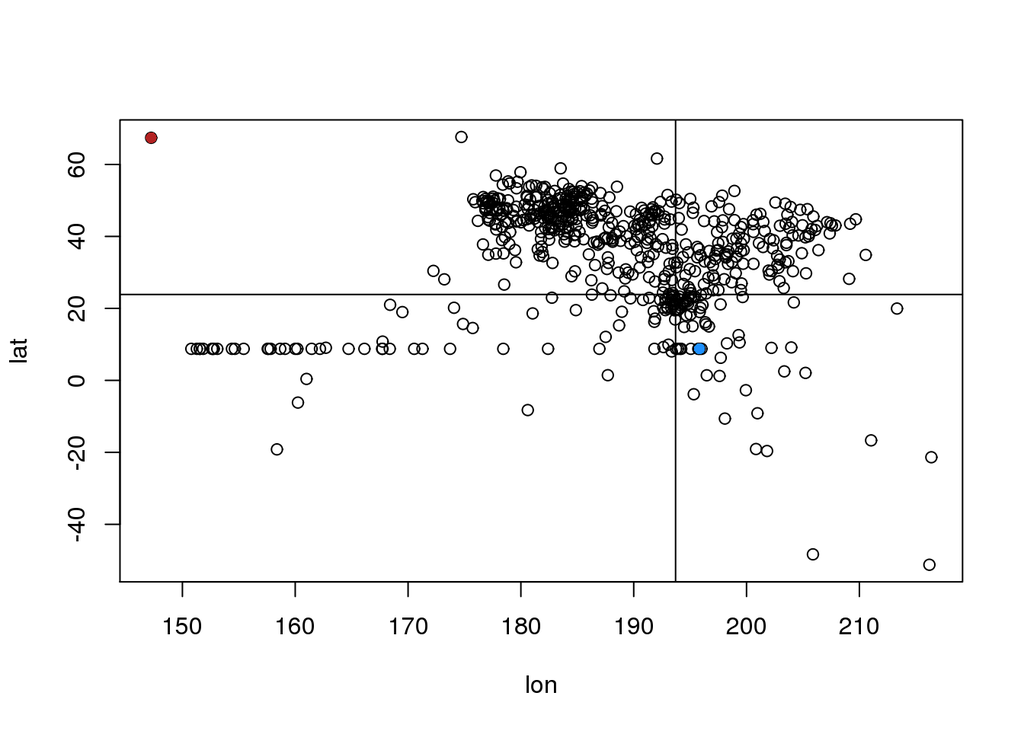

```r
## interleave rise and set
interleave <- function(x, y) {
  .POSIXct(as.vector(t(cbind(x, y))), tz = "GMT")
}
twl1 <- data.frame(Twilight = interleave(twl$Rise, twl$Set), Rise = c(TRUE, FALSE))

## add a new record for the recapture
twl1 <- rbind(twl1, data.frame(Twilight = ISOdatetime(2010, 1, 6, 0, 0, 0, tz = "GMT"), Rise = TRUE))
path1 <- threshold.path(twl1$Twilight, twl1$Rise, zenith = zenith)
x0 <- path1$x
x0[x0[,1] < 0, 1] <- x0[x0[,1] < 0, 1] + 360
plot(x0)
abline(h = lat.home, v = lon.home)
points(x0[1,,drop = FALSE], col = "dodgerblue", pch = 16)
points(x0[nrow(x0),,drop = FALSE], col = "firebrick", pch = 16)
```

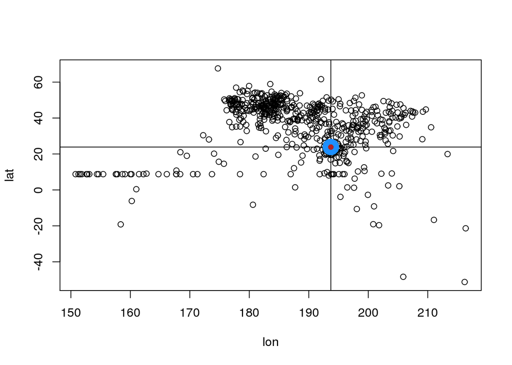

```r
## now fix our known locations
fixedx <- rep(FALSE, nlocation(x0))
fixedx[1L] <- TRUE
fixedx[length(fixedx)] <- TRUE
x0[fixedx,1] <- lon.home
x0[fixedx,2] <- lat.home
z0 <- trackMidpts(x0)
plot(x0)
abline(h = lat.home, v = lon.home)
points(x0[1,,drop = FALSE], col = "dodgerblue", pch = 16, cex = 3)
points(x0[nrow(x0),,drop = FALSE], col = "firebrick", pch = 16)
```

Now modify the starting points to also pass the prior constraints for the mask.

```r
bad <- log.prior(x0) < 0
x0[bad, 1] <- NA
x0[bad, 2] <- NA

library(zoo)
x0 <- na.approx(x0)
x0[fixedx,1] <- lon.home
x0[fixedx,2] <- lat.home
z0 <- trackMidpts(x0)
range(log.prior(x0))
```

```
## [1] 0 0
```

```r
range(log.prior(z0))
```

```
## [1] 0 0
```

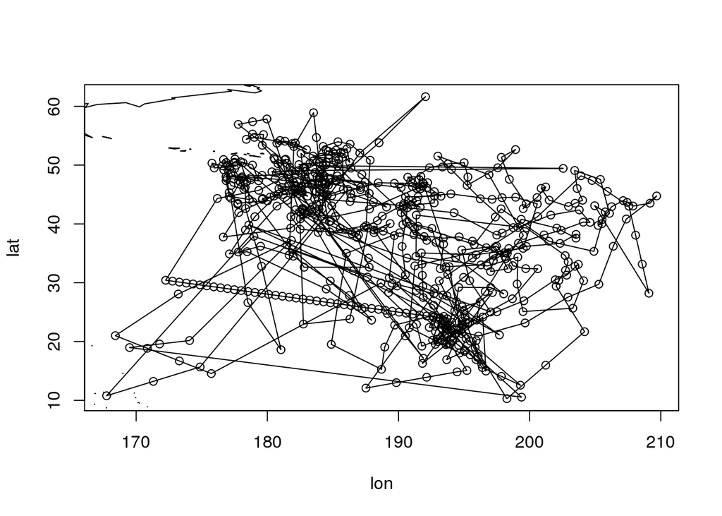

```r
plot(x0)
lines(x0)
plot(wrld_simpl, add = TRUE)
```

Choose parameters for the threshold sensitivity, and likely speed of movement. Bot the most likely speeds of travel and difference in time of twilight from the real twilight for our model are under the peak of the curve. We must supply these parameters a priori, there’s no way to estimate them from these data.

```r
## choose parameters
km <- trackDist(x0)
hr <- diff(as.numeric(twl1$Twilight))/3600
spd <- km/hr
mean(spd)
```

```
## [1] 31.13
```

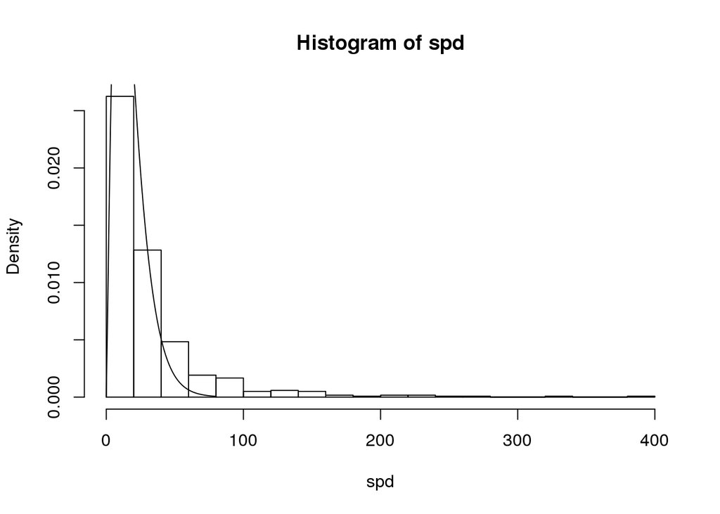

```r
hist(spd,15,freq=FALSE)
lines(0:80,dgamma(0:80,2.27,0.13))
```

```r
parameters.gamma(mean(spd[spd<50]),sd(spd[spd<50]))
```

```
##  shape   rate
## 1.9574 0.1121
```

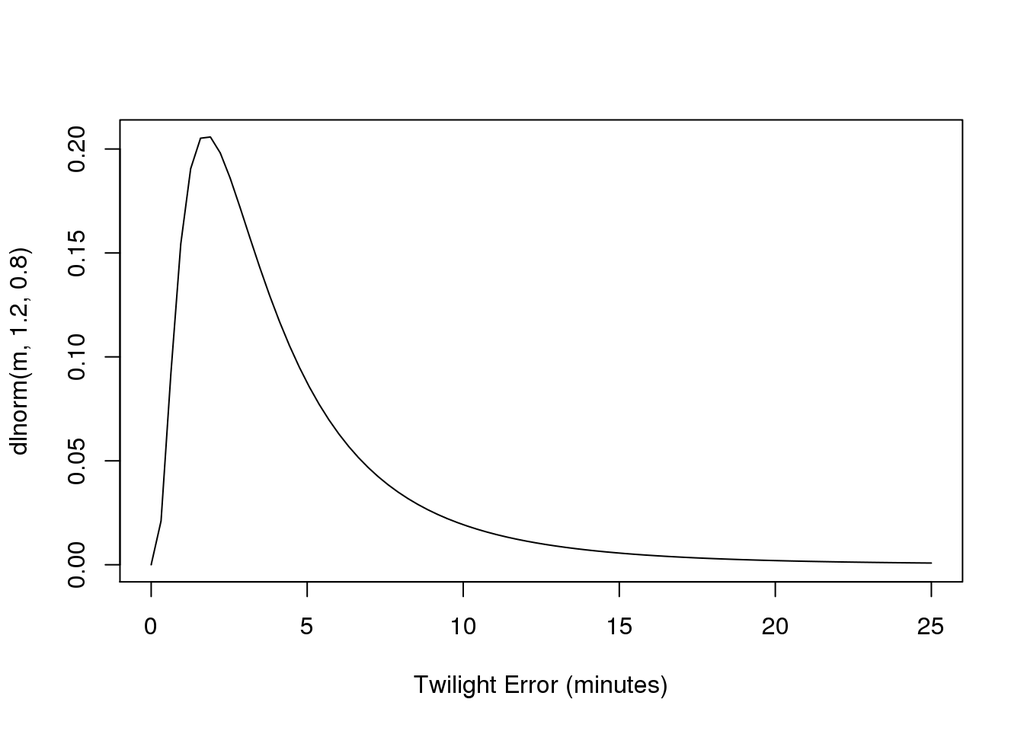

```r
m <- seq(0,25,length=80)
plot(m,dlnorm(m,1.2,0.8),type="l",xlab="Twilight Error (minutes)")
```

## Model

Now we build the model with these components, and run it.

```r
model <- threshold.model(twl1$Twilight, twl1$Rise,
                         twilight.model = "ModifiedLogNormal",
                         alpha = c(1.2,0.8), beta=c(1.95, 0.11),
                         logp.x=log.prior,logp.z=log.prior,
                         x0 = x0, z0 = z0, zenith = zenith, fixedx = fixedx)

x.proposal <- mvnorm(S=diag(c(0.005,0.005)),n=nlocation(x0))
z.proposal <- mvnorm(S=diag(c(0.005,0.005)),n=nlocation(z0))


fit <- estelle.metropolis(model,x.proposal,z.proposal,iters=100,thin=20,chains=1)
## In extreme circumstances, it may be necessary to manually intervene and adjust the
## estimates to ensure the constraints are met.
sapply(fit$x,function(x) all(fixedx | model$residuals(chain.last(x)) > 0))




x.proposal <- mvnorm(S=diag(c(0.005,0.005)),n=nlocation(x0))
z.proposal <- mvnorm(S=diag(c(0.005,0.005)),n=nlocation(z0))
fit <- estelle.metropolis(model,x.proposal,z.proposal,
                          iters=300,thin=20,chains=2)


plot(chain.last(chain.collapse(fit$x)))
lines(chain.last(chain.collapse(fit$x)))
for(k in 1:3) {
  x.proposal <- mvnorm(chain.cov(fit$x),s=0.2)
  z.proposal <- mvnorm(chain.cov(fit$z),s=0.2)
  fit <- estelle.metropolis(model,x.proposal,z.proposal,
                            x0=chain.last(fit$x),
                            z0=chain.last(fit$z),
                            iters=300,thin=20,chains=2)


  ## hope to see no obvious patterns in these chains
  ## once converged the values of each are constant within a range
  opar <- par(mfrow=c(length(fit$x),2),mar=c(3,5,2,1)+0.1)
  for(k in 1:length(fit$x)) {
    matplot(t(fit$x[[k]][!fixedx,1,]),type="l",lty=1,col="dodgerblue",ylab="Lon")
    matplot(t(fit$x[[k]][!fixedx,2,]),type="l",lty=1,col="firebrick",ylab="Lat")
  }
  par(opar)

}

xm <- apply(chain.collapse(fit$x), 1:2, mean)

## are we roughly on the right track?
plot(ldata$date, ldata$lon)
lines(twl1$Twilight, xm[,1])

plot(ldata$date, ldata$lat)
lines(twl1$Twilight, xm[,2])

x.proposal <- mvnorm(chain.cov(fit$x),s=0.25)
z.proposal <- mvnorm(chain.cov(fit$z),s=0.25)
fit <- estelle.metropolis(model,x.proposal,z.proposal,
                          x0=chain.last(fit$x),
                          z0=chain.last(fit$z),
                          iters=1000,thin=20,chains=2)



for (i in 1:4 ) {
  x.proposal <- mvnorm(chain.cov(fit$x),s=0.25)
  z.proposal <- mvnorm(chain.cov(fit$z),s=0.25)
  fit <- estelle.metropolis(model,x.proposal,z.proposal,
                            x0=chain.last(fit$x),
                            z0=chain.last(fit$z),
                            iters=3000,thin=10,chains=1)

  xm <- apply(chain.collapse(fit$x), 1:2, mean)
  op <- par(mfrow = c(2, 1))
  plot(ldata$date, ldata$lon)
  lines(twl1$Twilight, xm[,1])

  plot(ldata$date, ldata$lat)
  lines(twl1$Twilight, xm[,2])

  par(op)
}



## Fix the z locations.
fixedz <- fixedx[1:(length(fixedx)-1)] & fixedx[2:length(fixedx)]
for(k in 1:length(fit$z)) {
  fit$z[[k]][fixedz,1,] <- lon.home
  fit$z[[k]][fixedz,2,] <- lat.home
}


save.image("Lotek1.Rdata")
```